# R_phase1

Reza Pishkoo

#question1 #part a)i

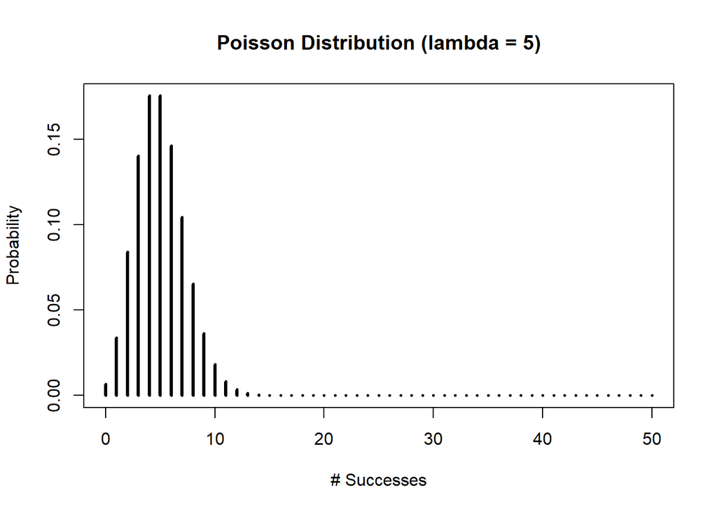

```r
success <- 0:50

plot(success, dpois(success, lambda=5),
     type='h',
     main='Poisson Distribution (lambda = 5)',
     ylab='Probability',
     xlab ='# Successes',
     lwd=3)
```

#part a)ii

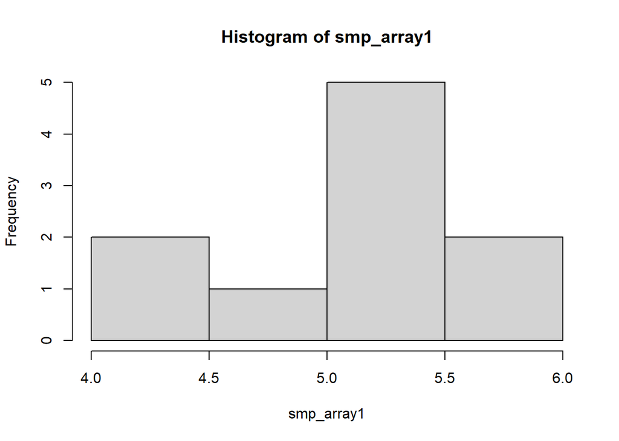

```r
x <- 1:10
smp_array1 = vector()
for (val in x) {
smp = rpois(50, lambda = 5)
mean_smp = mean(smp)
smp_array1 = c(smp_array1, mean_smp)
}
hist(smp_array1)
```

#to show the histogram of the means of 100 sample

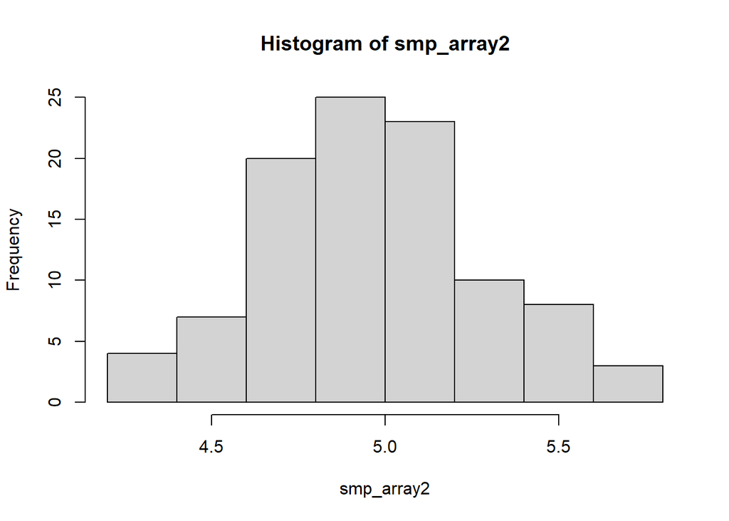

```r
x <- 1:100
smp_array2 = vector()
for (val in x) {
smp = rpois(50, lambda = 5)
mean_smp = mean(smp)
smp_array2 = c(smp_array2, mean_smp)
}
hist(smp_array2)
```

#to show the histogram of the means of 1000 sample

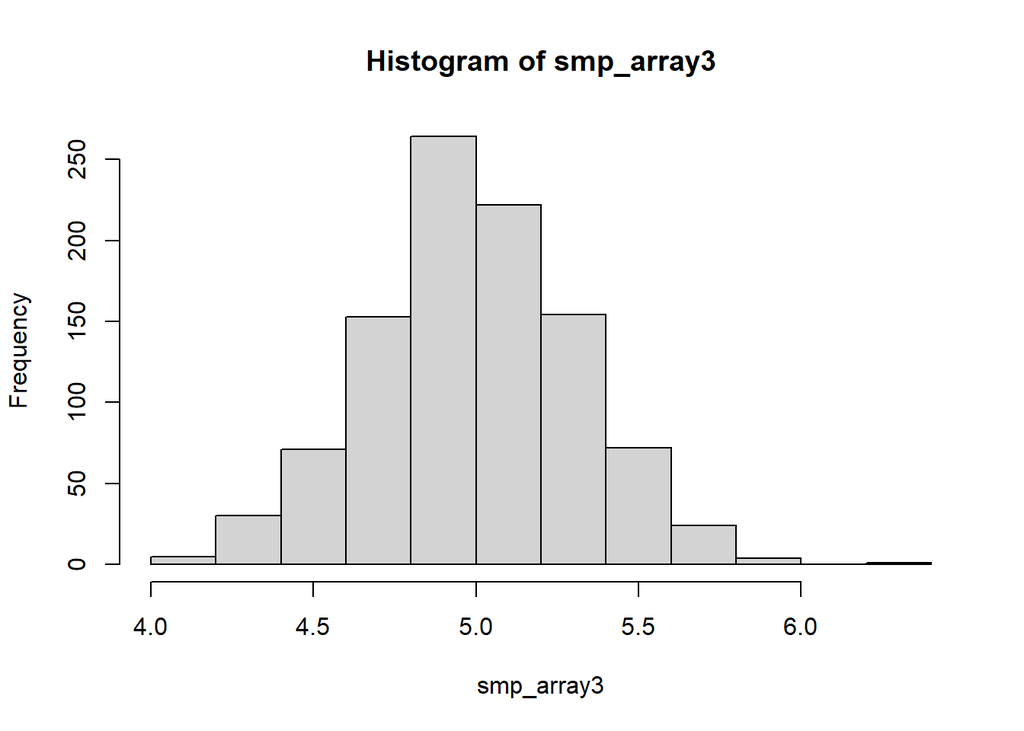

```r
x <- 1:1000
smp_array3 = vector()
for (val in x) {
smp = rpois(50, lambda = 5)
mean_smp = mean(smp)
smp_array3 = c(smp_array3, mean_smp)
}
hist(smp_array3)
```

#part a)iii

```r
mean_val1 = mean(smp_array1)
var_val1 = var(smp_array1)
cat("means of means for 10 sample : ",mean_val1, "\n")
```

```
## means of means for 10 sample :  5.088
```

```r
cat("var of means for 10 sample : ", var_val1, "\n")
```

```
## var of means for 10 sample :  0.2104178
```

```r
mean_val2 = mean(smp_array2)
var_val2 = var(smp_array2)
cat("means of means for 100 sample : ",mean_val2, "\n")
```

```
## means of means for 100 sample :  4.9842
```

```r
cat("var of means for 100 sample : ", var_val2, "\n")
```

```
## var of means for 100 sample :  0.1001478
```

```r
mean_val3 = mean(smp_array3)
var_val3 = var(smp_array3)
cat("means of means for 1000 sample : ",mean_val3, "\n")
```

```
## means of means for 1000 sample :  5.00106
```

```r
cat("var of means for 1000 sample : ", var_val3, "\n")
```

```
## var of means for 1000 sample :  0.09917125
```

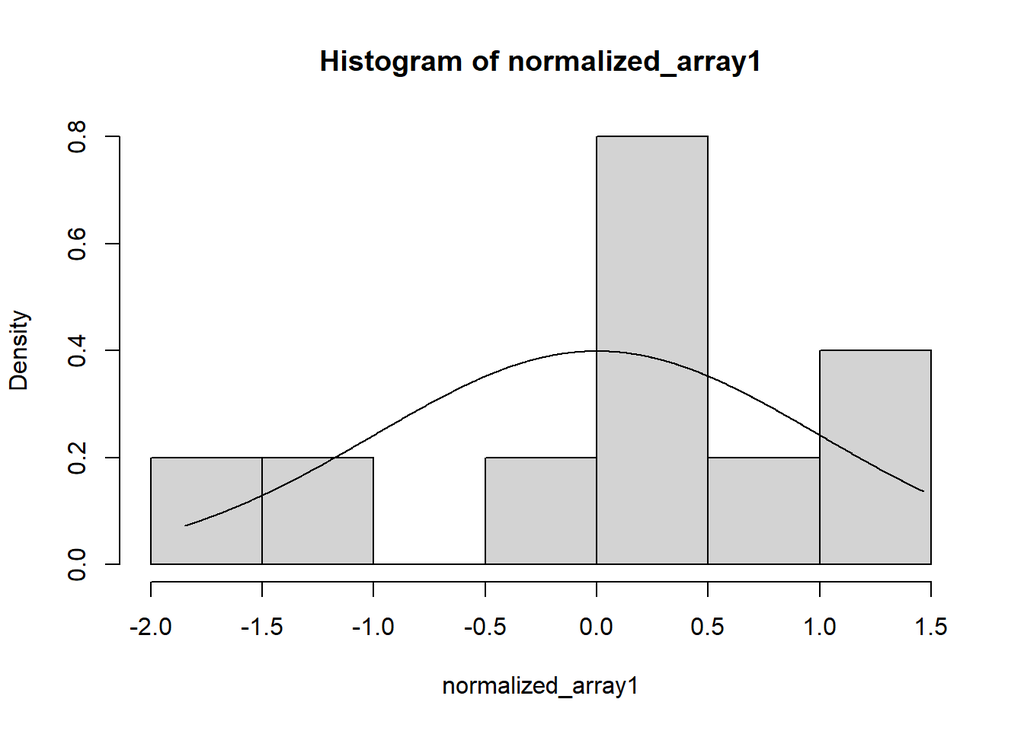

```r
normalized_array1 = smp_array1 - mean_val1
normalized_array1 = normalized_array1 / sqrt(var_val1)
hist(normalized_array1, prob=TRUE)
x <- seq(min(normalized_array1), max(normalized_array1), length=1000)
normal1 = dnorm(x)
lines(x, normal1)
```

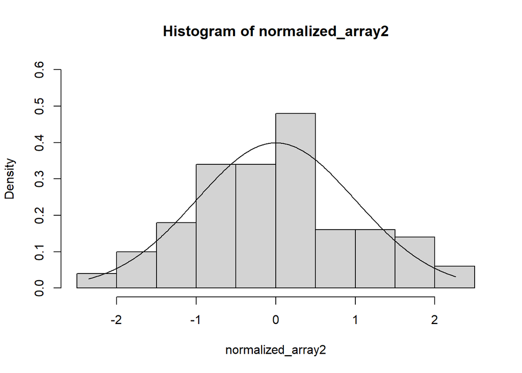

```r
normalized_array2 = smp_array2 - mean_val2
normalized_array2 = normalized_array2 / sqrt(var_val2)
hist(normalized_array2, prob=TRUE, ylim=c(0, 0.6))
x <- seq(min(normalized_array2), max(normalized_array2), length=1000)
normal2 = dnorm(x)
lines(x, normal2)
```

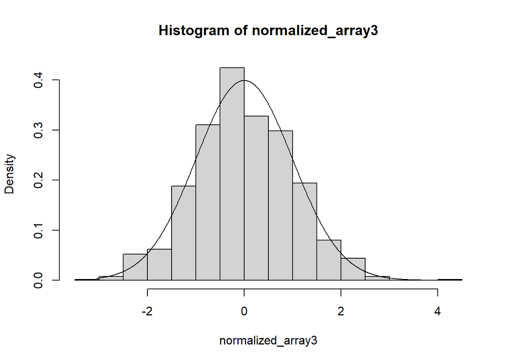

```r
normalized_array3 = smp_array3 - mean_val3
normalized_array3 = normalized_array3 / sqrt(var_val3)
hist(normalized_array3, prob=TRUE)
x <- seq(min(normalized_array3), max(normalized_array3), length=1000)
normal3 = dnorm(x)
lines(x, normal3)
```

مشاهده می شود که برای تعداد نمونه های بزرگ مانند 1000 تا به توزیع نرمال همگرا می شود که نشان دهنده درستی قضیه حد مرکزی است.

#part b)i

```r
library(fastR2)
birth_frame=group_by(Births,day_of_year)
birth_frame=summarise(birth_frame,day_mean=mean(births))
min = birth_frame[which.min(birth_frame$day_mean),]
max = birth_frame[which.max(birth_frame$day_mean),]
min[[1]]
```

```
## [1] 360
```

```r
max[[1]]
```

```
## [1] 260
```

#part b)ii

```r
birth_month=group_by(Births,month)
birth_month=summarize(birth_month,month_mean=mean(births))
sorted_mean=arrange(birth_month,desc(month_mean))
print(birth_month)
```

```
## # A tibble: 12 x 2
##    month month_mean
##    <int>      <dbl>
##  1     1      9289.
##  2     2      9491.
##  3     3      9465.
##  4     4      9268.
##  5     5      9331
##  6     6      9598.
##  7     7     10033.
##  8     8     10177.
##  9     9     10343.
## 10    10      9767.
## 11    11      9492.
## 12    12      9523.
```

```r
print(sorted_mean)
```

```
## # A tibble: 12 x 2
##    month month_mean
##    <int>      <dbl>
##  1     9     10343.
##  2     8     10177.
##  3     7     10033.
##  4    10      9767.
##  5     6      9598.
##  6    12      9523.
##  7    11      9492.
##  8     2      9491.
##  9     3      9465.
## 10     5      9331
## 11     1      9289.
## 12     4      9268.
```

#part c

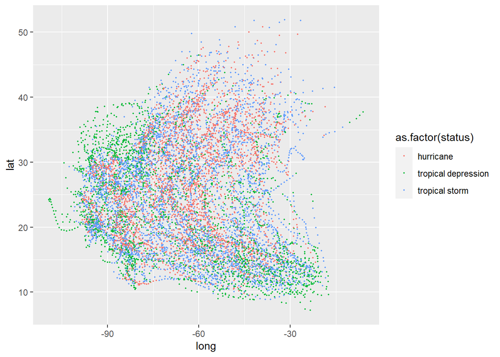

```r
library(dplyr)

st = mutate(storms,new_time=storms$year*24*366+storms$month*30*24+storms$day*24+storms$hour)

sorted_storms=storms[order(st$new_time),]

write.csv(sorted_storms[-ncol(sorted_storms)],"storms_report.csv")

sorted_storms$status=as.factor(sorted_storms$status)

ggplot() +geom_point( data=sorted_storms, aes(x=long, y=lat , color = as.factor(status)), size = 0.4)
```

#question2 #part a)i

```r
# Read TAB delimited files
had_dataframe = read.delim("had.txt", header = FALSE)
had_dataframe = data.frame(had_dataframe)
colnames(had_dataframe) = c("age", "sex", "pain", "blood", "cholesterol", "sugar", "heart_attack")
```

#part a)ii

```r
label = had_dataframe[7]
features = had_dataframe[-7]
```

#part a)iii

```r
num_data = nrow(label)
x = (80 * num_data) / 100
x = as.integer(x)
y = 1:num_data
rand_sample =sample(y, x)

train_label = label[rand_sample, ]
train_label = data.frame(train_label)
train_feature = features[rand_sample, ]

test_label = label[-rand_sample, ]
test_label = data.frame(test_label)
test_feature = features[-rand_sample, ]

write.table(train_feature, "train_feature.txt", row.names = FALSE, col.names = FALSE)
write.table(train_label, "train_label.txt", row.names = FALSE, col.names = FALSE)
write.table(test_feature, "test_feature.txt", row.names = FALSE, col.names = FALSE)
write.table(test_label, "test_label.txt", row.names = FALSE, col.names = FALSE)
```

#part b)i

```r
train_reg = lm(train_label$train_label ~ train_feature$age + train_feature$sex + train_feature$pain + train_feature$blood + train_feature$cholesterol + train_feature$sugar)

summary(train_reg)
```

```
##
## Call:
## lm(formula = train_label$train_label ~ train_feature$age + train_feature$sex +
##     train_feature$pain + train_feature$blood + train_feature$cholesterol +
##     train_feature$sugar)
##
## Residuals:
##      Min       1Q   Median       3Q      Max
## -2.09342 -0.63543  0.00362  0.66578  1.72912
##
## Coefficients:
##                            Estimate Std. Error t value Pr(>|t|)
## (Intercept)                2.411869   0.549628   4.388 1.73e-05 ***
## train_feature$age         -0.021749   0.006220  -3.497 0.000563 ***
## train_feature$sex         -0.553680   0.117114  -4.728 3.91e-06 ***
## train_feature$pain         0.345641   0.053457   6.466 5.77e-10 ***
## train_feature$blood       -0.003338   0.003347  -0.997 0.319641
## train_feature$cholesterol -0.002488   0.001208  -2.060 0.040520 *
## train_feature$sugar       -0.156646   0.163446  -0.958 0.338848
## ---
## Signif. codes:  0 '***' 0.001 '**' 0.01 '*' 0.05 '.' 0.1 ' ' 1
##
## Residual standard error: 0.8436 on 235 degrees of freedom
## Multiple R-squared:  0.2951, Adjusted R-squared:  0.2771
## F-statistic: 16.39 on 6 and 235 DF,  p-value: 9.214e-16
```

در قسمت call فرمولی نشان داده می شود که از آن برای حساب کردن رگرسیون استفاده کرده ایم.

در قسمت Residulas اختلاف مقادیر حقیقی و مقادیر پیشبینی شده نشان داده شده است.

در قسمت Estimate ضرایب به دست آمده از کمترین مجموع مربعات است.

در قسمت Std. Error انحراف معیار ضرایب نشان داده میشود.

در قسمت t value تقسیم ضریب و std error نمایش داده می شود که هر چه از صفر دور تر باشد یعنی ضرایب ما دقیق تر هستند.

در ستون آخر مقدار p value نشان داده می شود که به ما کمک میکند تا بفهمیم ضریب ما چقدر برای مدل معنا دار است. در عمل p value کمتر از 0.05 را معنی دار در نظر میگیریم.

در قسمت signif. codes راهی سری به ما داده می شود که بفهمیم کدام ضرایب برای مدل ما مهم هستند. تعداد ستاره ها با اهمیت ضریب مطابقت دارد. هر چه تعداد ستاره بیشتر باشد اهمیت بیشتری دارد.

قسمت Residual standard error معیاری است که نشان دهد مدل چقدر با داده تطابق دارد. در واقع میانگین تفاوت های مقادیر حقیقی با مقادیر پیشبینی شده را به ما می دهد.

#part b)ii

از لحاظ قدر مطلقی بیشترین مقدار مربوط به جنسیت و کمترین مقدار مربوط به میزان کلسترول است اما این مقایسه صحیح نیست زیرا متغیر ها در یک رنج نیستند برای مثال بین همین دو متغیر، جنسیت در بازه ی 0و 1 تغییر میکند در حال که میزان کلسترول بین 100 تا 600 متغیر است.

برای مقایسه پذیر شدن این ضرایب اول باید آنها را نرمال کنیم تا بازه تغییر آنها یکسان شود و در این حالت مقایسه ای که انجام می دهیم صحیح تر است.

#part c)i

```r
library(data.table)
facts = train_reg$coefficients
calculate <- function(limit){
  result = copy(test_label)
  for (i in 1:nrow(test_feature)){
    vals = test_feature[i,]
    res = sum(vals*facts[-1]) + facts[1]
    if(res > limit){
      result[i,] = 1
    }
    if(res < limit){
      result[i,] = -1
    }
  }
  return(sum(result$test_label == test_label$test_label)/nrow(test_label))
}

calculate(0)
```

```
## [1] 0.7540984
```

#part c)ii

```r
sequ = seq(-2, 2, 0.1)
vect = vector()
for (x in sequ){
  vect = c(vect, calculate(x))
}
rate_frame = data.frame(x=sequ, y=vect)
maximum_limit = rate_frame[which.max(rate_frame$y), ]
print(maximum_limit[[1]])
```

```
## [1] -0.1
```

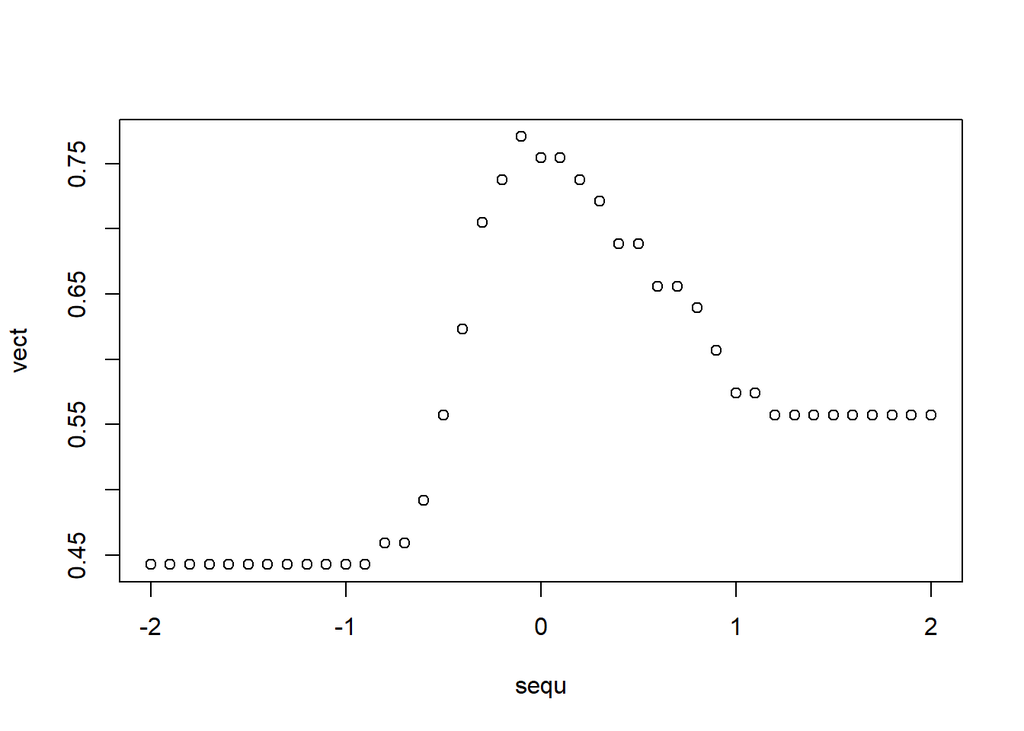

```r
plot(sequ, vect)
```

#quesion3 #part a)i

```r
library(readxl)
library(dplyr)

input = read_excel("input.xlsx", sheet=3)
```

```
## * `` -> ...2
## * `` -> ...3
## * `` -> ...4
## * `` -> ...5
## * `` -> ...6
## * ...
```

```r
input_prim = input[-1,]
input_prim = input_prim[-1,]
input_prim = input_prim[,-1]

to_del = vector()
num_deleted_clm = 0
for (col in 1:ncol(input_prim)) {
  x = length(lapply(input_prim[, col], as.numeric)[input_prim[,col]<10])
  print(x)
  if (x > 7){
    to_del = c(to_del, col)
  }
}
```

```
## [1] 0
## [1] 0
## [1] 0
## [1] 2
## [1] 0
## [1] 0
## [1] 0
```

```
## [1] 1
## [1] 0
## [1] 0
## [1] 0
```

```
## [1] 1
```

```
## [1] 2
## [1] 0
## [1] 0
## [1] 0
## [1] 0
## [1] 0
## [1] 0
## [1] 0
## [1] 0
## [1] 0
## [1] 0
## [1] 0
## [1] 0
## [1] 0
## [1] 0
## [1] 0
## [1] 0
## [1] 0
```

```
## [1] 1
## [1] 0
## [1] 0
## [1] 0
```

```
## [1] 1
```

```
## [1] 1
```

```
## [1] 4
```

```
## [1] 4
```

```
## [1] 6
```

```
## [1] 13
```

```
## [1] 9
```

```
## [1] 19
```

```
## [1] 18
## [1] 19
## [1] 8
```

#part a)ii

```r
library(readxl)
for (x in to_del){
  input = input[,-(x-num_deleted_clm + 1)]
  num_deleted_clm = num_deleted_clm + 1
}


input2 = input[-1,]
input2 = input2[-1,]
input2 = input2[,-1]
input2 = as.data.frame(sapply(input2, as.numeric))
View(input2)

tmp = na_if(input2, 0)
write.csv(tmp, file="cleared_data.csv")
```

#part b)i

```r
library(ggplot2)
my_row = tmp[14, ]
time_vector = c(1:ncol(my_row))
time_vector = rev(time_vector)
combined = rbind(my_row, time_vector)
rownames(combined) = c("price", "time")
combined <- t(combined)
combined = data.frame(combined)
reg = lm(data=combined, price ~ time)

print(summary(reg)$coefficient)
```

```
##              Estimate Std. Error    t value     Pr(>|t|)
## (Intercept) -2393.918  9290.1330 -0.2576839 7.980787e-01
## time         3005.110   404.8126  7.4234606 7.789390e-09
```

```r
print(summary(reg)$sigma)
```

```
## [1] 28452.31
```

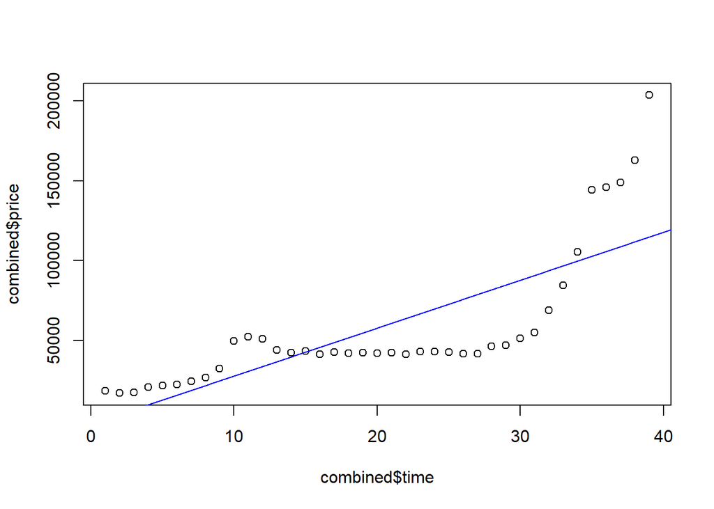

```r
plot(y=combined$price, x=combined$time)
abline(reg, col="blue")
```

#part b)ii

```r
price = vector()
time = vector()
region = vector()

tmp = t(tmp)
tmp = t(tmp)
t = c(1:ncol(tmp))
t = rev(t)

for (i in 1:39){
  price = c(price, tmp[, i])
  time = c(time, rep(i, 23))
  region = c(region, seq(1, 23))
}
ptr_combined = data.frame(region, time, price)
reg = lm(data=ptr_combined, price ~ time + region)

print(summary(reg))
```

```
##
## Call:
## lm(formula = price ~ time + region, data = ptr_combined)
##
## Residuals:
##    Min     1Q Median     3Q    Max
## -83665 -28960  -7931  17820 389190
##
## Coefficients:
##             Estimate Std. Error t value Pr(>|t|)
## (Intercept) 180285.6     4718.8   38.21   <2e-16 ***
## time         -3609.7      155.8  -23.16   <2e-16 ***
## region       -4156.3      260.4  -15.96   <2e-16 ***
## ---
## Signif. codes:  0 '***' 0.001 '**' 0.01 '*' 0.05 '.' 0.1 ' ' 1
##
## Residual standard error: 51100 on 871 degrees of freedom
##   (23 observations deleted due to missingness)
## Multiple R-squared:  0.4729, Adjusted R-squared:  0.4717
## F-statistic: 390.7 on 2 and 871 DF,  p-value: < 2.2e-16
```

#part b)iii

```r
indicator_mat = matrix(0, nrow(ptr_combined), 22)
for (i in seq(1:nrow(ptr_combined))){
  if (i%%23 < 14){
    indicator_mat[i, i%%23] = 1
  }
  if (i%%23 > 14){
    indicator_mat[i, (i-1)%%23] = 1
  }
  if(i%%23 == 0){
    indicator_mat[i, 22] = 1
  }
}
ptr_combined = data.frame(indicator_mat, time, price)
reg = lm(data=ptr_combined, price ~ .)

print(summary(reg))
```

```
##
## Call:
## lm(formula = price ~ ., data = ptr_combined)
##
## Residuals:
##    Min     1Q Median     3Q    Max
## -68219 -31639  -7844  19686 346937
##
## Coefficients:
##             Estimate Std. Error t value Pr(>|t|)
## (Intercept) 130357.4     8128.7  16.037  < 2e-16 ***
## X1            7867.1    10741.2   0.732 0.464108
## X2           67862.5    10741.2   6.318 4.27e-10 ***
## X3           60212.4    10741.2   5.606 2.80e-08 ***
## X4           75578.7    10741.2   7.036 4.06e-12 ***
## X5           25870.6    10741.2   2.409 0.016228 *
## X6           14404.4    10741.2   1.341 0.180262
## X7           49320.8    10811.8   4.562 5.82e-06 ***
## X8           20130.8    10741.2   1.874 0.061250 .
## X9            9675.6    10741.2   0.901 0.367949
## X10         -21622.9    11045.3  -1.958 0.050596 .
## X11         -17131.2    10741.2  -1.595 0.111103
## X12         -18230.9    10741.2  -1.697 0.090008 .
## X13         -23246.2    10741.2  -2.164 0.030725 *
## X14          -9742.7    10811.7  -0.901 0.367776
## X15         -27828.1    10811.7  -2.574 0.010224 *
## X16         -27226.3    10964.8  -2.483 0.013217 *
## X17         -36838.9    11047.5  -3.335 0.000891 ***
## X18         -35013.3    10811.8  -3.238 0.001249 **
## X19         -34182.5    11129.8  -3.071 0.002200 **
## X20         -38176.2    10741.2  -3.554 0.000400 ***
## X21         -23012.2    10962.7  -2.099 0.036099 *
## X22         -10536.9    10741.2  -0.981 0.326879
## time         -3632.5      144.8 -25.081  < 2e-16 ***
## ---
## Signif. codes:  0 '***' 0.001 '**' 0.01 '*' 0.05 '.' 0.1 ' ' 1
##
## Residual standard error: 47430 on 850 degrees of freedom
##   (23 observations deleted due to missingness)
## Multiple R-squared:  0.5567, Adjusted R-squared:  0.5447
## F-statistic: 46.41 on 23 and 850 DF,  p-value: < 2.2e-16
```

#part b)iv

روش دوم بهتر است زیرا که انحراف معیار کمتری دارد. چون در این حالت هر منطفه را جدا در نظر گرفتیم و ضریب خودش را دارد و با توجه به جاهای مختلف شهر تخمین بهتری میتوان زد.